# Minimum ORF length and target-decoy acceptance of ORFs

This notebook supports the Results subsections *Minimum ORF length and target-decoy acceptance of ORFs* and *Small inputs and presets* (results_short_orfs.tex), the q-value paragraphs of the Methods (methods_algorithm.tex, *ORF selection*, *Target-decoy q-values*, *Presets for small inputs*) and Fig. 4 (`figures/fig4_short_orfs.{pdf,png}`).

Which data each part uses:

- **Release runs** (E25; PyTD 3a793ff, identical to Perl 41fc5ee on all 84 inputs): `data/benchmark/final_v7/negatives_scores.tsv` (default q 0.05 = `pytd_v7`, `--precise` q 0.01, `--sensitive` q 0.2, plus the development runs `cliff_c200` and `dev_q*` scored the same way), and tables derived from the release predictions by `pipeline/derive/04_release_short_orfs.sh` (`by_length.v7.tsv`, `sens_by_length.v7.tsv`, `lnc_by_era.human.v7.tsv`, `lnc_call_lengths.human.tsv`, `lnc_riboseq_orfs.v7.tsv`).
- **Development runs, no release equivalent**: the minimum-length sweep (100 to 50 codons; `short_orf_summary.tsv`, `by_length.tsv`; E04), the q sweep from 0.01 to 0.5 and the longest-ORF baselines (`qmodes/`; E22), the decoy prototype and calibration (`rules/`; E20) and the held-out preset test (`presets/`; E21). These were run with the same rule but an earlier random number generator (E24); where a release value exists it is shown next to the development value.

"Fixed short-ORF test" is the development default before the q-value test (`cliff_c200`: 50-codon minimum, frame contrast of at least 200·μ below 100 codons; `m50+g200` in E04).

```r
N_LNC <- c(human = 33668, mouse = 31467)
N_RAND <- c(human = 19167, mouse = 21409, dmel = 13884, athal = 26867, spombe = 5100,
            tthermophila = 26456, pfalciparum = 5281, creinhardtii = 17621)
VARS <- c("complete.wRand", "fragments.wRand", "complete.wLnc", "fragments.wLnc")
VAR_LABEL <- c(complete.wRand = "complete + random", fragments.wRand = "fragments + random",
               complete.wLnc = "complete + lncRNA", fragments.wLnc = "fragments + lncRNA")
REL_LABEL <- c(precise = "--precise (q 0.01)", pytd_v7 = "default (q 0.05)",
               sensitive = "--sensitive (q 0.2)")

sos <- read_tab("benchmark", "short_orf_summary.tsv")
bylen <- read_tab("benchmark", "by_length.tsv")
bylen7 <- read_tab("benchmark", "final_v7", "by_length.v7.tsv")
neg7 <- read_tab("benchmark", "final_v7", "negatives_scores.tsv")
qmed <- read_tab("benchmark", "qmodes", "qmodes.medians.tsv")
cal <- read_tab("benchmark", "rules", "decoy_calibration.per_input.tsv")
sbl <- read_tab("benchmark", "rules", "sens_by_length.decoy.tsv")
sbl7 <- read_tab("benchmark", "final_v7", "sens_by_length.v7.tsv")
lnc_len <- read_tab("benchmark", "final_v7", "lnc_call_lengths.human.tsv")
ribo_dev <- read_tab("benchmark", "rules", "lnc_riboseq_orfs.tsv")
ribo7 <- read_tab("benchmark", "final_v7", "lnc_riboseq_orfs.v7.tsv")
era7 <- read_tab("benchmark", "final_v7", "lnc_by_era.human.v7.tsv")
presets <- read_tab("benchmark", "presets", "preset_scores.tsv") %>%
  mutate(set = sub("\\.r[0-9]+$", "", variant))

# short_orf_summary.awk applied to by_length.v7.tsv (release runs)
summarise_bylen <- function(b) {
  b %>% group_by(org, v = variant, tool) %>%
    summarise(sens_all = sum(tp_stop[kind == "truth"]) / sum(n[kind == "truth"]),
              sens_short = sum(tp_stop[kind == "truth" & grepl("^[5-9]0-", bin)]) /
                sum(n[kind == "truth" & grepl("^[5-9]0-", bin)]),
              neg = sum(fp_negative[kind == "pred"]), fp_real = sum(fp_real[kind == "pred"]),
              tp = sum(tp_stop[kind == "pred"]), .groups = "drop") %>%
    mutate(prec = tp / (tp + fp_real + neg))
}
sos7 <- summarise_bylen(bylen7) %>%
  mutate(cfg = recode(tool, pytd_v7 = "q0.05", pytd_v7_precise = "q0.01", pytd_v7_sensitive = "q0.2"))

# medians over organisms of the release and development runs scored by score_negatives.py
med7 <- neg7 %>% group_by(variant, label) %>%
  summarise(across(c(sens_stop, sens_exact, precision_stop, neg_rate), median), n_orgs = n(),
            .groups = "drop")
m7 <- function(v, l, col) med7[[col]][med7$variant == v & med7$label == l]
mq <- function(v, l, col) qmed[[col]][qmed$variant == v & qmed$label == l]
```

## Random sequence understates the cost of short ORFs

Development minimum-length sweep (E04; no release rerun exists for LongOrfs minima other than 50). `neg` counts predictions on negatives; one random sequence per truth transcript.

```r
s <- function(o, v, cfg, col) sos[[col]][sos$org == o & sos$v == v & sos$cfg == cfg]
rand_m50 <- sos %>% filter(v == "complete.wRand", cfg == "m50") %>%
  mutate(n_rand = N_RAND[org], per_seq = neg / n_rand) %>% arrange(per_seq)
h_sens100 <- s("human", "complete.wLnc", "m100", "sens_short")
h_sens50 <- s("human", "complete.wLnc", "m50", "sens_short")
h_lnc100 <- s("human", "complete.wLnc", "m100", "neg")
h_lnc50 <- s("human", "complete.wLnc", "m50", "neg")
h_prec100 <- s("human", "complete.wLnc", "m100", "prec")
h_prec50 <- s("human", "complete.wLnc", "m50", "prec")
short_bins <- c("50-59", "60-69", "70-79", "80-89", "90-99")
bl50 <- bylen %>% filter(org == "human", variant == "complete.wLnc", tool == "pytd_dev_m50",
                         kind == "pred", bin %in% short_bins)
lnc_short <- sum(bl50$fp_negative)
tp_short <- sum(bl50$tp_stop)
# release default, human complete.wLnc, for comparison
r7 <- sos7 %>% filter(org == "human", v == "complete.wLnc", cfg == "q0.05")
check_text("random calls per sequence at 50 codons, min", round(min(rand_m50$per_seq), 3), 0.013)
check_text("random calls per sequence at 50 codons, max", round(max(rand_m50$per_seq), 3), 0.159)
check_text("human lncRNA negatives", N_LNC[["human"]], 33668)
check_text("human 50-99 aa sensitivity, 100 codons", round(h_sens100, 2), 0.31)
check_text("human 50-99 aa sensitivity, 50 codons", round(h_sens50, 2), 0.86)
check_text("human lncRNAs with prediction, 100 codons (%)", round(100 * h_lnc100 / N_LNC[["human"]], 1), 19.6)
check_text("human lncRNAs with prediction, 50 codons (%)", round(100 * h_lnc50 / N_LNC[["human"]], 1), 63.6)
check_text("human precision, 100 codons", round(h_prec100, 2), 0.74)
check_text("human precision, 50 codons", round(h_prec50, 2), 0.47)
check_text("lncRNA calls of 50-99 aa at 50 codons", lnc_short, 14880)
check_text("correct calls of 50-99 aa at 50 codons", tp_short, 430)
```

- At a 50-codon minimum, 0.013–0.159 calls per GC-matched random sequence (C. reinhardtii 228 / 17,621 to S. pombe 813 / 5,100).
- Human complete transcripts with 33,668 lncRNA negatives, 100 → 50 codons: sensitivity for true proteins of 50–99 aa 0.311 → 0.859; lncRNAs with a prediction 6,608 (19.6%) → 21,416 (63.6%); precision 0.737 → 0.468.
- In the 50–99 aa range at 50 codons: 14,880 lncRNA calls against 430 correct calls.
- For comparison, the release default (q 0.05) on the same input: 50–99 aa sensitivity 0.391, 1,639 lncRNAs with a prediction (4.9%), precision 0.918 (`by_length.v7.tsv`).

The minimum-length sweep exists only as development runs (no release rerun of LongOrfs minima other than 50), so the paragraph's numbers stay on the sweep. The release q settings (q 0.01, 0.05, 0.2) are added to Fig. 4a,b as the blue paths and the release default to Fig. 4c (section *Figure 4*); the earlier asking for this update has been resolved in the text and the caption.

## A target-decoy test for every ORF

Medians over organisms (eight with random negatives, human and mouse with lncRNA negatives). "release" is `pytd_v7` (E25), the run the manuscript quotes; "fixed" is `cliff_c200`; "dev q 0.05" is the development run an earlier draft quoted (`decoy_q0.05_longgc`, E20/E22), rescored in the same file.

```r
tab_decoy <- med7 %>% filter(label %in% c("pytd_v7", "dev_q0.05", "cliff_c200")) %>%
  mutate(label = recode(label, pytd_v7 = "release q 0.05", dev_q0.05 = "dev q 0.05",
                        cliff_c200 = "fixed short-ORF test"),
         variant = factor(variant, VARS), neg_pct = round(100 * neg_rate, 2)) %>%
  arrange(variant, label) %>% select(variant, label, sens_stop, sens_exact, neg_pct, n_orgs)
kable(tab_decoy, digits = 3, col.names = c("input", "setting", "stop sens.", "exact sens.",
                                           "% negatives with prediction", "organisms"))
```

| input | setting | stop sens. | exact sens. | % negatives with prediction | organisms |
| --- | --- | --- | --- | --- | --- |
| complete.wRand | dev q 0.05 | 0.965 | 0.899 | 0.36 | 8 |
| complete.wRand | fixed short-ORF test | 0.957 | 0.897 | 0.48 | 8 |
| complete.wRand | release q 0.05 | 0.964 | 0.899 | 0.29 | 8 |
| fragments.wRand | dev q 0.05 | 0.872 | 0.773 | 0.22 | 8 |
| fragments.wRand | fixed short-ORF test | 0.815 | 0.708 | 0.11 | 8 |
| fragments.wRand | release q 0.05 | 0.872 | 0.772 | 0.23 | 8 |
| complete.wLnc | dev q 0.05 | 0.964 | 0.894 | 4.95 | 2 |
| complete.wLnc | fixed short-ORF test | 0.976 | 0.905 | 18.92 | 2 |
| complete.wLnc | release q 0.05 | 0.963 | 0.893 | 5.04 | 2 |
| fragments.wLnc | dev q 0.05 | 0.857 | 0.755 | 5.83 | 2 |
| fragments.wLnc | fixed short-ORF test | 0.858 | 0.753 | 18.65 | 2 |
| fragments.wLnc | release q 0.05 | 0.858 | 0.756 | 5.89 | 2 |

```r
rel <- function(v, col) m7(v, "pytd_v7", col)
fix <- function(v, col) m7(v, "cliff_c200", col)
# values quoted in the bullet list (release q 0.05 against the fixed short-ORF test)
quoted <- tribble(
  ~variant, ~col, ~q_rel, ~q_fix,
  "complete.wRand", "sens_stop", 0.964, 0.957,
  "complete.wRand", "sens_exact", 0.899, 0.897,
  "complete.wRand", "neg_rate", 0.29, 0.48,
  "fragments.wRand", "sens_stop", 0.872, 0.815,
  "fragments.wRand", "sens_exact", 0.772, 0.708,
  "fragments.wRand", "neg_rate", 0.23, 0.11,
  "complete.wLnc", "neg_rate", 5.0, 18.9,
  "fragments.wLnc", "neg_rate", 5.9, 18.7,
  "complete.wLnc", "sens_stop", 0.963, 0.976,
  "fragments.wLnc", "sens_stop", 0.858, 0.858)
for (i in seq_len(nrow(quoted))) {
  q <- quoted[i, ]
  isneg <- q$col == "neg_rate"
  sc <- if (isneg) 100 else 1
  dg <- if (isneg) (if (grepl("Lnc", q$variant)) 1 else 2) else 3
  check_text(sprintf("%s %s, q-value test", VAR_LABEL[[q$variant]], q$col),
             round(sc * rel(q$variant, q$col), dg), q$q_rel)
  # exact value compared at half a unit of the quoted digit (medians such as 0.1865 round either way)
  check_text(sprintf("%s %s, fixed short-ORF test", VAR_LABEL[[q$variant]], q$col),
             sc * fix(q$variant, q$col), q$q_fix, tol = 0.5 * 10^-dg)
}
```

Release values: complete + random stop 0.964 against 0.957, exact 0.899 against 0.897, 0.29% against 0.48% of random sequences; fragments + random stop 0.872 against 0.815, exact 0.772 against 0.708, at 0.23% against 0.11%; lncRNA negatives 5.0% against 18.9% (complete) and 5.9% against 18.6% (fragments), at stop sensitivity 0.963 against 0.976 and 0.858 against 0.858. E25, E20.

### Strata: transcript length matters on fragments

Prototype post-filter (`rules/decoy_proto/`, E20): stop sensitivity on fragments with strata of ORF length only (`len`) against ORF length × transcript length × ORF type (`len_tx_type`, the release strata), at the same q.

```r
proto_files <- list.files(data_path("benchmark", "rules", "decoy_proto"), pattern = "fragments.*\\.di\\.len",
                          full.names = TRUE)
proto <- bind_rows(lapply(proto_files, read_tsv, show_col_types = FALSE)) %>%
  tidyr::separate(label, c("org", "variant", "strata"), sep = "\\.", extra = "merge") %>%
  mutate(variant = paste(variant, sub("\\..*", "", strata), sep = "."), strata = sub(".*\\.", "", strata))
proto_gain <- proto %>% filter(q_cutoff %in% c(0.05, 0.1)) %>%
  select(org, variant, strata, q_cutoff, sens_stop) %>%
  pivot_wider(names_from = strata, values_from = sens_stop) %>%
  mutate(gain_tx_type = 100 * (len_tx_type - len), gain_tx = 100 * (len_tx - len))
kable(proto_gain, digits = 3)
```

| org | variant | q_cutoff | len_tx_type | len_tx | len | gain_tx_type | gain_tx |
| --- | --- | --- | --- | --- | --- | --- | --- |
| athal | fragments.wRand | 0.05 | 0.794 | 0.775 | 0.712 | 8.23 | 6.36 |
| athal | fragments.wRand | 0.1 | 0.821 | 0.803 | 0.742 | 7.83 | 6.12 |
| dmel | fragments.wRand | 0.05 | 0.857 | 0.853 | 0.818 | 3.97 | 3.56 |
| dmel | fragments.wRand | 0.1 | 0.868 | 0.864 | 0.831 | 3.70 | 3.27 |
| human | fragments.wLnc | 0.05 | 0.860 | 0.849 | 0.802 | 5.80 | 4.67 |
| human | fragments.wLnc | 0.1 | 0.881 | 0.874 | 0.829 | 5.24 | 4.51 |
| human | fragments.wRand | 0.05 | 0.882 | 0.873 | 0.827 | 5.46 | 4.62 |
| human | fragments.wRand | 0.1 | 0.904 | 0.894 | 0.849 | 5.53 | 4.51 |

Adding transcript length and ORF type to the strata raised stop sensitivity on fragments by 3.7–8.2 points (athal, dmel, human; q 0.05 and 0.1). The text's "5–6 points" matches the median (5.5).

```r
check_text("strata gain on fragments, points (median, text 5-6)", round(median(proto_gain$gain_tx_type)),
           5.5, tol = 0.5)
```

### Sensitivity by CDS length

Pooled over organisms, stop sensitivity for true CDSs of 50–74 codons (`sens_by_length.py`; development `rules/sens_by_length.decoy.tsv` and release `final_v7/sens_by_length.v7.tsv`).

```r
sbl_all <- bind_rows(sbl %>% mutate(source = "development"),
                     sbl7 %>% filter(label != "cliff_c200") %>% mutate(source = "release")) %>%
  filter(set == "coding") %>%
  group_by(source, variant, label, length_bin) %>% summarise(n = sum(n), hits = sum(hits), .groups = "drop") %>%
  mutate(sens = hits / n)
lb <- function(v, l, b) sbl_all$sens[sbl_all$variant == v & sbl_all$label == l & sbl_all$length_bin == b]
tab_len <- sbl_all %>% filter(length_bin %in% c("50-74", "75-99", "100-124")) %>%
  select(-hits) %>% pivot_wider(names_from = length_bin, values_from = c(sens, n)) %>%
  mutate(variant = factor(variant, VARS)) %>% arrange(variant, source, label)
details(tab_len %>% mutate(across(starts_with("sens"), ~ round(.x, 3))), "sensitivity by CDS length (50-124 codons)")
```

**sensitivity by CDS length (50-124 codons)**

| source | variant | label | sens_100-124 | sens_50-74 | sens_75-99 | n_100-124 | n_50-74 | n_75-99 |
| --- | --- | --- | --- | --- | --- | --- | --- | --- |
| development | complete.wRand | cliff_c200 | 0.845 | 0.184 | 0.419 | 4370 | 2076 | 3540 |
| development | complete.wRand | decoy_q0.05 | 0.722 | 0.330 | 0.508 | 4370 | 2076 | 3540 |
| development | complete.wRand | decoy_q0.1 | 0.786 | 0.357 | 0.581 | 4370 | 2076 | 3540 |
| development | complete.wRand | decoy_q0.2 | 0.813 | 0.405 | 0.638 | 4370 | 2076 | 3540 |
| development | complete.wRand | taper_c150 | 0.708 | 0.201 | 0.451 | 4370 | 2076 | 3540 |
| development | complete.wRand | taper_c200 | 0.627 | 0.108 | 0.317 | 4370 | 2076 | 3540 |
| release | complete.wRand | pytd_v7 | 0.741 | 0.314 | 0.536 | 4370 | 2076 | 3540 |
| release | complete.wRand | pytd_v7_precise | 0.617 | 0.279 | 0.412 | 4370 | 2076 | 3540 |
| release | complete.wRand | pytd_v7_sensitive | 0.817 | 0.411 | 0.640 | 4370 | 2076 | 3540 |
| development | fragments.wRand | cliff_c200 | 0.943 | 0.273 | 0.547 | 12145 | 11626 | 12027 |
| development | fragments.wRand | decoy_q0.05 | 0.878 | 0.517 | 0.745 | 12145 | 11626 | 12027 |
| development | fragments.wRand | decoy_q0.1 | 0.913 | 0.615 | 0.822 | 12145 | 11626 | 12027 |
| development | fragments.wRand | decoy_q0.2 | 0.928 | 0.713 | 0.868 | 12145 | 11626 | 12027 |
| development | fragments.wRand | taper_c150 | 0.825 | 0.311 | 0.624 | 12145 | 11626 | 12027 |
| development | fragments.wRand | taper_c200 | 0.736 | 0.163 | 0.466 | 12145 | 11626 | 12027 |
| release | fragments.wRand | pytd_v7 | 0.877 | 0.529 | 0.753 | 12145 | 11626 | 12027 |
| release | fragments.wRand | pytd_v7_precise | 0.747 | 0.368 | 0.578 | 12145 | 11626 | 12027 |
| release | fragments.wRand | pytd_v7_sensitive | 0.928 | 0.713 | 0.866 | 12145 | 11626 | 12027 |
| development | complete.wLnc | cliff_c200 | 0.909 | 0.265 | 0.603 | 987 | 313 | 746 |
| development | complete.wLnc | decoy_q0.05 | 0.685 | 0.201 | 0.437 | 987 | 313 | 746 |
| development | complete.wLnc | decoy_q0.1 | 0.742 | 0.217 | 0.492 | 987 | 313 | 746 |
| development | complete.wLnc | decoy_q0.2 | 0.822 | 0.278 | 0.611 | 987 | 313 | 746 |
| development | complete.wLnc | taper_c150 | 0.789 | 0.272 | 0.606 | 987 | 313 | 746 |
| development | complete.wLnc | taper_c200 | 0.713 | 0.176 | 0.476 | 987 | 313 | 746 |
| release | complete.wLnc | pytd_v7 | 0.662 | 0.204 | 0.424 | 987 | 313 | 746 |
| release | complete.wLnc | pytd_v7_precise | 0.538 | 0.192 | 0.330 | 987 | 313 | 746 |
| release | complete.wLnc | pytd_v7_sensitive | 0.833 | 0.268 | 0.588 | 987 | 313 | 746 |
| development | fragments.wLnc | cliff_c200 | 0.962 | 0.350 | 0.623 | 3928 | 3083 | 3626 |
| development | fragments.wLnc | decoy_q0.05 | 0.827 | 0.491 | 0.682 | 3928 | 3083 | 3626 |
| development | fragments.wLnc | decoy_q0.1 | 0.896 | 0.587 | 0.784 | 3928 | 3083 | 3626 |
| development | fragments.wLnc | decoy_q0.2 | 0.945 | 0.709 | 0.879 | 3928 | 3083 | 3626 |
| development | fragments.wLnc | taper_c150 | 0.844 | 0.381 | 0.690 | 3928 | 3083 | 3626 |
| development | fragments.wLnc | taper_c200 | 0.759 | 0.204 | 0.539 | 3928 | 3083 | 3626 |
| release | fragments.wLnc | pytd_v7 | 0.826 | 0.499 | 0.688 | 3928 | 3083 | 3626 |
| release | fragments.wLnc | pytd_v7_precise | 0.658 | 0.345 | 0.506 | 3928 | 3083 | 3626 |
| release | fragments.wLnc | pytd_v7_sensitive | 0.944 | 0.688 | 0.871 | 3928 | 3083 | 3626 |

```r
check_text("fragments 50-74 codon sensitivity, fixed test", round(lb("fragments.wRand", "cliff_c200", "50-74"), 2), 0.27)
check_text("fragments 50-74 codon sensitivity, q 0.1 (dev)", round(lb("fragments.wRand", "decoy_q0.1", "50-74"), 2), 0.62)
```

Fragments with random negatives, 50–74 codons: 0.273 with the fixed test, 0.615 at development q 0.1 (the value quoted), and in the release runs 0.368, 0.529 and 0.713 at q 0.01, 0.05 and 0.2. There is no release run at q 0.1. On complete + lncRNA inputs, the fixed test is higher at 100–124 codons (0.909 against 0.662 for the release default), where it accepted any positive contrast.

### Calibration

Observed false-discovery rate = 1 − stop precision of the final predictions, median per input type.

```r
cal_dev <- cal %>% filter(label %in% c("decoy_q0.01", "decoy_q0.05", "decoy_q0.1", "decoy_q0.2")) %>%
  group_by(variant, label) %>% summarise(observed_fdr = median(observed_fdr_stop), .groups = "drop") %>%
  mutate(source = "development", q = as.numeric(sub("decoy_q", "", label)))
cal_rel <- neg7 %>% filter(label %in% names(REL_LABEL)) %>% group_by(variant, label) %>%
  summarise(observed_fdr = median(1 - precision_stop), .groups = "drop") %>%
  mutate(source = "release", q = c(precise = 0.01, pytd_v7 = 0.05, sensitive = 0.2)[label])
cal_tab <- bind_rows(cal_dev, cal_rel) %>% select(source, variant, q, observed_fdr) %>%
  pivot_wider(names_from = variant, values_from = observed_fdr) %>% arrange(source, q)
kable(cal_tab, digits = 4)
```

| source | q | complete.wLnc | complete.wRand | fragments.wLnc | fragments.wRand |
| --- | --- | --- | --- | --- | --- |
| development | 0.01 | 0.0614 | 0.0050 | 0.0798 | 0.0040 |
| development | 0.05 | 0.0742 | 0.0056 | 0.0969 | 0.0069 |
| development | 0.10 | 0.0888 | 0.0060 | 0.1211 | 0.0093 |
| development | 0.20 | 0.1129 | 0.0065 | 0.1608 | 0.0125 |
| release | 0.01 | 0.0689 | 0.0058 | 0.0863 | 0.0045 |
| release | 0.05 | 0.0796 | 0.0061 | 0.1022 | 0.0077 |
| release | 0.20 | 0.1169 | 0.0079 | 0.1596 | 0.0129 |

```r
cd <- function(v) cal_dev$observed_fdr[cal_dev$variant == v & cal_dev$label == "decoy_q0.1"]
check_text("observed FDR complete + lncRNA at q 0.1", round(cd("complete.wLnc"), 3), 0.089)
check_text("observed FDR fragments + lncRNA at q 0.1", round(cd("fragments.wLnc"), 3), 0.121)
check_text("observed FDR complete + random at q 0.1", round(cd("complete.wRand"), 3), 0.006)
check_text("observed FDR fragments + random at q 0.1", round(cd("fragments.wRand"), 3), 0.009)
```

At a nominal 0.1 (development, `decoy_q0.1` without the long-ORF rule, as E20): observed 0.089 and 0.121 on lncRNA negatives, 0.006 and 0.009 on random negatives. The release runs at q 0.05 give 0.080 and 0.102 on lncRNA negatives. Note that the q-values are computed over all candidate ORFs, while the observed rate is over the one selected per transcript.

## One setting

```r
d_lnc <- function(v) 100 * (m7(v, "pytd_v7", "sens_stop") - m7(v, "precise", "sens_stop"))
d_lnc_dev <- function(v) 100 * (m7(v, "dev_q0.05", "sens_stop") - m7(v, "dev_q0.01", "sens_stop"))
ll <- function(l, col, v = "complete.wLnc") lnc_len[[col]][lnc_len$label == l & lnc_len$variant == v]
lo100 <- function(v, col) mq(v, "longest_orf_m100", col)
kable(lnc_len, caption = "Human lncRNA calls by predicted ORF length (codons, stop included)")
```

Human lncRNA calls by predicted ORF length (codons, stop included)

| variant | label | source | n_lnc_calls | ge100 | ge200 | ge300 |
| --- | --- | --- | --- | --- | --- | --- |
| complete.wLnc | pytd_v7 | release | 1639 | 1354 | 656 | 236 |
| complete.wLnc | pytd_v7_precise | release | 1378 | 1133 | 623 | 236 |
| complete.wLnc | pytd_v7_sensitive | release | 2685 | 2075 | 688 | 235 |
| complete.wLnc | decoy_q0.01_longgc | development | 1322 | 1112 | 613 | 236 |
| complete.wLnc | decoy_q0.02_longgc | development | 1437 | 1214 | 630 | 236 |
| complete.wLnc | decoy_q0.05_longgc | development | 1618 | 1363 | 638 | 236 |
| complete.wLnc | decoy_q0.1_longgc | development | 1954 | 1638 | 666 | 235 |
| complete.wLnc | decoy_q0.2_longgc | development | 2549 | 1990 | 688 | 234 |
| complete.wLnc | decoy_q0.3_longgc | development | 3396 | 2453 | 697 | 234 |
| complete.wLnc | decoy_q0.5_longgc | development | 5278 | 3159 | 713 | 234 |
| fragments.wLnc | pytd_v7 | release | 1928 | 1542 | 670 | 235 |
| fragments.wLnc | pytd_v7_precise | release | 1507 | 1244 | 646 | 235 |
| fragments.wLnc | pytd_v7_sensitive | release | 3621 | 2394 | 734 | 234 |
| fragments.wLnc | decoy_q0.01_longgc | development | 1469 | 1223 | 642 | 235 |
| fragments.wLnc | decoy_q0.02_longgc | development | 1553 | 1284 | 648 | 235 |
| fragments.wLnc | decoy_q0.05_longgc | development | 1873 | 1500 | 658 | 235 |
| fragments.wLnc | decoy_q0.1_longgc | development | 2553 | 1857 | 680 | 235 |
| fragments.wLnc | decoy_q0.2_longgc | development | 3648 | 2413 | 707 | 234 |
| fragments.wLnc | decoy_q0.3_longgc | development | 4833 | 2902 | 730 | 233 |
| fragments.wLnc | decoy_q0.5_longgc | development | 7318 | 3783 | 751 | 232 |

```r
check_text("--precise lncRNA calls, complete (%)", round(100 * m7("complete.wLnc", "precise", "neg_rate"), 1), 4.2)
check_text("--precise lncRNA calls, fragments (%)", round(100 * m7("fragments.wLnc", "precise", "neg_rate"), 1), 4.6)
check_text("--precise stop sensitivity cost, complete + lncRNA (points)", round(d_lnc("complete.wLnc"), 1), 1.3)
check_text("--precise stop sensitivity cost, fragments + lncRNA (points)", round(d_lnc("fragments.wLnc"), 1), 6.4)
check_text("human lncRNA calls >= 200 codons at q 0.01", ll("pytd_v7_precise", "ge200"), 623)
check_text("human lncRNA calls at q 0.01", ll("pytd_v7_precise", "n_lnc_calls"), 1378)
check_text("human lncRNA calls >= 300 codons at q 0.01", ll("pytd_v7_precise", "ge300"), 236)
check_text("human lncRNA calls >= 300 codons at q 0.3 (dev only)", ll("decoy_q0.3_longgc", "ge300"), 234)
check_text("--sensitive fragments + random stop sensitivity", round(m7("fragments.wRand", "sensitive", "sens_stop"), 3), 0.895)
check_text("q 0.3 fragments + random stop sensitivity (dev only)", mq("fragments.wRand", "decoy_q0.3", "sens_stop"), 0.898, tol = 0.0005)
check_text("q 0.5 fragments + random stop sensitivity (dev only)", round(mq("fragments.wRand", "decoy_q0.5", "sens_stop"), 3), 0.898)
check_text("--sensitive lncRNA calls, complete (%)", round(100 * m7("complete.wLnc", "sensitive", "neg_rate"), 1), 7.8)
check_text("--sensitive lncRNA calls, fragments (%)", round(100 * m7("fragments.wLnc", "sensitive", "neg_rate"), 1), 10.2)
check_text("--sensitive random calls below 0.5% (max of complete/fragments, %)",
           as.numeric(100 * max(m7("complete.wRand", "sensitive", "neg_rate"), m7("fragments.wRand", "sensitive", "neg_rate")) < 0.5), 1)
check_text("longest ORF >= 100 codons, random calls complete (%)", round(100 * lo100("complete.wRand", "neg_rate")), 22)
check_text("longest ORF >= 100 codons, random calls fragments (%)", round(100 * lo100("fragments.wRand", "neg_rate")), 11)
check_text("longest ORF >= 100 codons, lncRNA calls (%)", round(100 * lo100("complete.wLnc", "neg_rate")), 26)
check_text("longest ORF >= 100 codons, stop sens complete + random", round(lo100("complete.wRand", "sens_stop"), 3), 0.954)
check_text("longest ORF >= 100 codons, stop sens fragments + random", round(lo100("fragments.wRand", "sens_stop"), 3), 0.759)
```

- `--precise` (release): lncRNA calls 4.2% and 4.6% (development q 0.01: 4.1% and 4.5%), at a cost of 1.3 and 6.4 points of stop sensitivity against the release default on complete and fragment lncRNA inputs (development: 1.4 and 6.7).
- Human complete + lncRNA, calls by length: at q 0.01 (release) 623 of 1,378 lncRNA calls are at least 200 codons (development: 613 of 1,322); calls of at least 300 codons: 236, 236 and 235 at release q 0.01, 0.05 and 0.2, and 234 at development q 0.3.
- `--sensitive` (release): fragments + random stop sensitivity 0.895, against 0.897 and 0.898 at development q 0.3 and 0.5 (not rerun); lncRNA calls 7.8% and 10.2%; random calls 0.40% and 0.45%.
- Longest ORF of at least 100 codons per transcript (from the LongOrfs output of the development runs; LongOrfs is unchanged at release): random calls 22.3% and 11.3%, lncRNA calls 25.7%, stop sensitivity 0.954 and 0.759. E22.

### Catalogued Ribo-seq ORFs among lncRNA calls

Human lncRNA predictions that end at the stop codon of a GENCODE phase-2 Ribo-seq ORF (`score_lnc_riboseq_orfs.py`, comprehensive catalogue). The derived release table repeats `cliff_c200` and `decoy_q0.05`, which reproduce the development table exactly.

```r
ribo_all <- bind_rows(ribo_dev %>% mutate(source = "development"),
                      ribo7 %>% filter(grepl("pytd_v7", label)) %>% mutate(source = "release")) %>%
  mutate(frac = lnc_pred_cat / lnc_pred)
ribo_rep <- inner_join(ribo_dev, ribo7, by = c("org", "variant", "label"))
stopifnot(all(ribo_rep$lnc_pred.x == ribo_rep$lnc_pred.y), all(ribo_rep$lnc_pred_cat.x == ribo_rep$lnc_pred_cat.y))
details(ribo_all %>% mutate(frac = round(frac, 4)), "lncRNA calls at catalogued Ribo-seq ORF stops")
```

**lncRNA calls at catalogued Ribo-seq ORF stops**

| org | variant | label | n_lnc | lnc_pred | lnc_pred_cat | cat_orfs | cat_found | source | frac |
| --- | --- | --- | --- | --- | --- | --- | --- | --- | --- |
| human | complete.wLnc | cliff_c0 | 33668 | 21416 | 219 | 698 | 158 | development | 0.0102 |
| human | complete.wLnc | cliff_c200 | 33668 | 6943 | 92 | 698 | 67 | development | 0.0133 |
| human | complete.wLnc | taper_c150 | 33668 | 3827 | 53 | 698 | 43 | development | 0.0138 |
| human | complete.wLnc | taper_c200 | 33668 | 2533 | 31 | 698 | 24 | development | 0.0122 |
| human | complete.wLnc | taper_c250 | 33668 | 1983 | 24 | 698 | 19 | development | 0.0121 |
| human | complete.wLnc | fixed_c150 | 33668 | 3894 | 45 | 698 | 36 | development | 0.0116 |
| human | complete.wLnc | fixed_c200 | 33668 | 2046 | 18 | 698 | 16 | development | 0.0088 |
| human | complete.wLnc | inverse_c200 | 33668 | 2398 | 26 | 698 | 20 | development | 0.0108 |
| human | complete.wLnc | curve_c150 | 33668 | 3880 | 52 | 698 | 41 | development | 0.0134 |
| human | complete.wLnc | curve_c200 | 33668 | 2783 | 41 | 698 | 33 | development | 0.0147 |
| human | complete.wLnc | perl_td_v571 | 33668 | 6598 | 110 | 698 | 78 | development | 0.0167 |
| human | complete.wLnc | cpat | 33668 | 3520 | 62 | 698 | 50 | development | 0.0176 |
| human | complete.wLnc | cpc2 | 33668 | 2660 | 26 | 698 | 22 | development | 0.0098 |
| human | complete.wLnc | rnasamba | 33668 | 3057 | 44 | 698 | 34 | development | 0.0144 |
| human | complete.wLnc | gmst | 33668 | 8275 | 106 | 698 | 81 | development | 0.0128 |
| human | complete.wLnc | prodigal | 33668 | 11888 | 174 | 698 | 105 | development | 0.0146 |
| human | fragments.wLnc | cliff_c0 | 33668 | 21100 | 218 | 698 | 160 | development | 0.0103 |
| human | fragments.wLnc | cliff_c200 | 33668 | 6833 | 87 | 698 | 64 | development | 0.0127 |
| human | fragments.wLnc | taper_c150 | 33668 | 3710 | 52 | 698 | 38 | development | 0.0140 |
| human | fragments.wLnc | taper_c200 | 33668 | 2512 | 29 | 698 | 22 | development | 0.0115 |
| human | fragments.wLnc | taper_c250 | 33668 | 1939 | 22 | 698 | 18 | development | 0.0113 |
| human | fragments.wLnc | fixed_c150 | 33668 | 3756 | 49 | 698 | 35 | development | 0.0130 |
| human | fragments.wLnc | fixed_c200 | 33668 | 2012 | 20 | 698 | 15 | development | 0.0099 |
| human | fragments.wLnc | inverse_c200 | 33668 | 2381 | 29 | 698 | 23 | development | 0.0122 |
| human | fragments.wLnc | curve_c150 | 33668 | 4210 | 57 | 698 | 42 | development | 0.0135 |
| human | fragments.wLnc | curve_c200 | 33668 | 2520 | 33 | 698 | 24 | development | 0.0131 |
| human | fragments.wLnc | perl_td_v571 | 33668 | 6496 | 109 | 698 | 79 | development | 0.0168 |
| human | fragments.wLnc | cpat | 33668 | 3520 | 62 | 698 | 50 | development | 0.0176 |
| human | fragments.wLnc | cpc2 | 33668 | 2660 | 26 | 698 | 22 | development | 0.0098 |
| human | fragments.wLnc | rnasamba | 33668 | 2581 | 25 | 698 | 21 | development | 0.0097 |
| human | fragments.wLnc | gmst | 33668 | 9398 | 134 | 698 | 102 | development | 0.0143 |
| human | fragments.wLnc | prodigal | 33668 | 18525 | 346 | 698 | 228 | development | 0.0187 |
| human | complete.wLnc | decoy_q0.05 | 33668 | 1451 | 13 | 698 | 12 | development | 0.0090 |
| human | complete.wLnc | decoy_q0.1 | 33668 | 1807 | 19 | 698 | 17 | development | 0.0105 |
| human | complete.wLnc | decoy_q0.2 | 33668 | 2428 | 26 | 698 | 22 | development | 0.0107 |
| human | fragments.wLnc | decoy_q0.05 | 33668 | 1734 | 16 | 698 | 13 | development | 0.0092 |
| human | fragments.wLnc | decoy_q0.1 | 33668 | 2443 | 22 | 698 | 16 | development | 0.0090 |
| human | fragments.wLnc | decoy_q0.2 | 33668 | 3560 | 43 | 698 | 31 | development | 0.0121 |
| human | complete.wLnc | pytd_v7 | 33668 | 1639 | 14 | 698 | 13 | release | 0.0085 |
| human | complete.wLnc | pytd_v7_precise | 33668 | 1378 | 13 | 698 | 12 | release | 0.0094 |
| human | complete.wLnc | pytd_v7_sensitive | 33668 | 2685 | 25 | 698 | 21 | release | 0.0093 |
| human | fragments.wLnc | pytd_v7 | 33668 | 1928 | 18 | 698 | 14 | release | 0.0093 |
| human | fragments.wLnc | pytd_v7_precise | 33668 | 1507 | 14 | 698 | 11 | release | 0.0093 |
| human | fragments.wLnc | pytd_v7_sensitive | 33668 | 3621 | 43 | 698 | 33 | release | 0.0119 |

```r
check_text("Ribo-seq ORF share of lncRNA calls, min (%)", round(100 * min(ribo_all$frac)), 1, tol = 0.5)
check_text("Ribo-seq ORF share of lncRNA calls, max (%)", round(100 * max(ribo_all$frac)), 2, tol = 0.5)
```

Over all 44 runs, 0.9–1.9% of lncRNA predictions end at a catalogued Ribo-seq ORF stop; the release default gives 0.9% on complete transcripts.

## lncRNAs by GENCODE era

Recomputed for the release runs with `analyses/lnc_holdout/lnc_calls_by_era.py` (`pipeline/derive/04_release_short_orfs.sh` → `final_v7/lnc_by_era.human.v7.tsv`). The comparator rows are the same runs as in E04 and reproduce `lnc_by_era.human.tsv` exactly.

```r
era_old <- read_lines(data_path("benchmark", "lnc_by_era.human.tsv"))
era_dev <- tibble(line = era_old) %>%
  mutate(variant = ifelse(startsWith(line, "=="), sub("== ", "", line), NA)) %>% fill(variant) %>%
  filter(!startsWith(line, "=="), !startsWith(line, "tool")) %>%
  separate(line, c("tool", "era", "n_lnc", "n_called", "frac_called"), sep = "\t", convert = TRUE)
chk <- inner_join(era_dev, era7, by = c("variant", "tool", "era"))
stopifnot(nrow(chk) == nrow(era_dev), all(chk$n_called.x == chk$n_called.y))
era_tab <- era7 %>% group_by(variant, tool) %>%
  summarise(pre_v28 = n_called[era == "pre_v28"] / n_lnc[era == "pre_v28"],
            post_v28 = n_called[era == "post_v28"] / n_lnc[era == "post_v28"],
            all = sum(n_called) / sum(n_lnc), .groups = "drop") %>%
  mutate(ratio_post_pre = post_v28 / pre_v28)
kable(era_tab %>% filter(variant == "complete.wLnc") %>% arrange(-all), digits = 3)
```

| variant | tool | pre_v28 | post_v28 | all | ratio_post_pre |
| --- | --- | --- | --- | --- | --- |
| complete.wLnc | prodigal | 0.341 | 0.361 | 0.353 | 1.058 |
| complete.wLnc | gmst | 0.266 | 0.233 | 0.246 | 0.879 |
| complete.wLnc | borf | 0.259 | 0.216 | 0.233 | 0.835 |
| complete.wLnc | pytd_dev_v2 | 0.220 | 0.197 | 0.206 | 0.895 |
| complete.wLnc | cpat | 0.109 | 0.102 | 0.105 | 0.938 |
| complete.wLnc | rnasamba | 0.062 | 0.109 | 0.091 | 1.742 |
| complete.wLnc | pytd_v7_sensitive | 0.060 | 0.092 | 0.080 | 1.528 |
| complete.wLnc | cpc2 | 0.079 | 0.079 | 0.079 | 0.995 |
| complete.wLnc | pytd_v7 | 0.034 | 0.058 | 0.049 | 1.685 |
| complete.wLnc | pytd_v7_precise | 0.029 | 0.049 | 0.041 | 1.692 |

```r
details(era_tab %>% filter(variant == "fragments.wLnc") %>% arrange(-all) %>% mutate(across(where(is.numeric), ~ round(.x, 3))),
        "fragments + lncRNA")
```

**fragments + lncRNA**

| variant | tool | pre_v28 | post_v28 | all | ratio_post_pre |
| --- | --- | --- | --- | --- | --- |
| fragments.wLnc | prodigal | 0.546 | 0.553 | 0.550 | 1.014 |
| fragments.wLnc | gmst | 0.302 | 0.264 | 0.279 | 0.874 |
| fragments.wLnc | borf | 0.259 | 0.216 | 0.233 | 0.835 |
| fragments.wLnc | pytd_dev_v2 | 0.217 | 0.194 | 0.203 | 0.891 |
| fragments.wLnc | pytd_v7_sensitive | 0.094 | 0.116 | 0.108 | 1.237 |
| fragments.wLnc | cpat | 0.109 | 0.102 | 0.105 | 0.938 |
| fragments.wLnc | cpc2 | 0.079 | 0.079 | 0.079 | 0.995 |
| fragments.wLnc | rnasamba | 0.046 | 0.096 | 0.077 | 2.069 |
| fragments.wLnc | pytd_v7 | 0.045 | 0.065 | 0.057 | 1.459 |
| fragments.wLnc | pytd_v7_precise | 0.035 | 0.051 | 0.045 | 1.466 |

```r
e <- function(t, col) era_tab[[col]][era_tab$variant == "complete.wLnc" & era_tab$tool == t]
fe <- function(t) { x <- era7 %>% filter(variant == "complete.wLnc", tool == t)
  fisher.test(matrix(c(x$n_called, x$n_lnc - x$n_called), 2))$p.value }
check_text("TransDecoder lncRNA calls, in GENCODE v28 (%)", round(100 * e("pytd_v7", "pre_v28"), 1), 3.4)
check_text("TransDecoder lncRNA calls, added later (%)", round(100 * e("pytd_v7", "post_v28"), 1), 5.8)
check_text("TransDecoder lncRNA calls, ratio added later / in v28", round(e("pytd_v7", "ratio_post_pre"), 2), 1.68)
check_text("TransDecoder lncRNA calls, Fisher p (x 1e-23)", round(fe("pytd_v7") / 1e-23, 1), 2.4)
check_text("RNAsamba lncRNA calls, in v28 (%)", round(100 * e("rnasamba", "pre_v28"), 1), 6.2)
check_text("RNAsamba lncRNA calls, added later (%)", round(100 * e("rnasamba", "post_v28"), 1), 10.9)
check_text("RNAsamba lncRNA calls, ratio", round(e("rnasamba", "ratio_post_pre"), 2), 1.74)
check_text("CPAT lncRNA calls, ratio", round(e("cpat", "ratio_post_pre"), 2), 0.94)
check_text("CPC2 lncRNA calls, ratio", round(e("cpc2", "ratio_post_pre"), 2), 1.00)
check_text("TransDecoder lncRNA call rate (%)", round(100 * e("pytd_v7", "all"), 1), 4.9)
check_text("CPAT lncRNA call rate (%)", round(100 * e("cpat", "all"), 1), 10.5)
check_text("CPC2 lncRNA call rate (%)", round(100 * e("cpc2", "all"), 1), 7.9)
check_text("RNAsamba lncRNA call rate (%)", round(100 * e("rnasamba", "all"), 1), 9.1)
```

Release default (q 0.05), human complete + lncRNA: TransDecoder predicted an ORF in 3.4% of lncRNAs already in GENCODE v28 and 5.8% of those added later (ratio 1.68; Fisher's exact test p = 2.4e-23), and 4.9% overall, below CPAT (10.5%), RNAsamba (9.1%) and CPC2 (7.9%). With the fixed short-ORF test (development, `pytd_dev_v2`) the rates were 22.0% and 19.7% (20.6% overall). RNAsamba: 6.2% and 10.9% (ratio 1.74).

Under the q-value rule TransDecoder, which was not trained on any lncRNA annotation, calls newer lncRNAs more often than older ones, by about the same factor as RNAsamba. The RNAsamba era difference therefore no longer stands out as a sign of training-data overlap: older lncRNAs may simply be less ORF-like (for example, better studied or longer-established noncoding genes), and the q-value rule removes the short marginal calls that previously hid this. E04, E25.

## Figure 4

Panels (release runs are the filled symbols; development runs keep their earlier role):

```r
REL_CFG <- c("q0.01", "q0.05", "q0.2")
ab <- bind_rows(sos %>% filter(cfg %in% c("m100", "m90", "m80", "m70", "m60", "m50", "m50+g200")),
                sos7 %>% filter(cfg %in% REL_CFG) %>% select(org, v, cfg, sens_all, sens_short, neg, fp_real, prec)) %>%
  filter(org %in% c("human", "mouse"), v %in% c("complete.wLnc", "fragments.wLnc")) %>%
  mutate(x = 100 * neg / N_LNC[org], y = 100 * sens_short,
         path = case_when(cfg %in% REL_CFG ~ "release", cfg == "m50+g200" ~ "fixed", TRUE ~ "minimum"),
         label = case_when(path == "minimum" ~ sub("m", "", cfg), path == "release" ~ sub("q", "q ", cfg), TRUE ~ ""))
per_neg <- bind_rows(sos %>% filter(cfg %in% c("m100", "m50", "m50+g200")),
                     sos7 %>% filter(cfg == "q0.05")) %>%
  filter((v == "complete.wRand") | (v == "complete.wLnc" & org %in% c("human", "mouse"))) %>%
  mutate(n_neg = ifelse(v == "complete.wLnc", N_LNC[org], N_RAND[org]), per_seq = neg / n_neg,
         group = ifelse(v == "complete.wLnc", "lncRNAs", "GC-matched random sequences"),
         cfg = factor(cfg, c("m100", "m50", "m50+g200", "q0.05"),
                      c("100 codons", "50 codons", "fixed test", "release q 0.05")),
         org_lab = factor(ORG_LABEL[org], ORG_LABEL[ORGS]))
era_plot <- era7 %>% filter(variant == "complete.wLnc", tool %in% c("pytd_v7", "cpat", "cpc2", "rnasamba", "borf", "gmst", "prodigal"))
TOOL_LABEL <- c(pytd_v7 = "TransDecoder", prodigal = "Prodigal", gmst = "GeneMarkS-T", borf = "Borf",
                cpat = "CPAT", rnasamba = "RNAsamba", cpc2 = "CPC2")
ord <- era_plot %>% group_by(tool) %>% summarise(all = sum(n_called) / sum(n_lnc)) %>% arrange(-all)
era_plot <- era_plot %>% mutate(tool = factor(TOOL_LABEL[tool], TOOL_LABEL[ord$tool]),
                                era = factor(era, c("pre_v28", "post_v28"), c("in GENCODE v28", "added after v28")),
                                pct = 100 * frac_called)
qs <- qmed %>% filter(grepl("^decoy_q", label)) %>% mutate(q = as.numeric(sub("decoy_q", "", label)), kind = "dev q sweep")
other <- qmed %>% filter(label %in% c("cliff_c200", "longest_orf_m100", "longest_orf_m50")) %>%
  mutate(kind = recode(label, cliff_c200 = "fixed short-ORF test", longest_orf_m100 = "longest ORF ≥ 100 codons",
                       longest_orf_m50 = "longest ORF ≥ 50 codons"))
relp <- med7 %>% filter(label %in% names(REL_LABEL)) %>% mutate(kind = REL_LABEL[label])
e_dat <- bind_rows(qs, other, relp) %>% mutate(x = 100 * neg_rate, y = sens_stop,
                                               variant = factor(VAR_LABEL[variant], VAR_LABEL[VARS]))
```

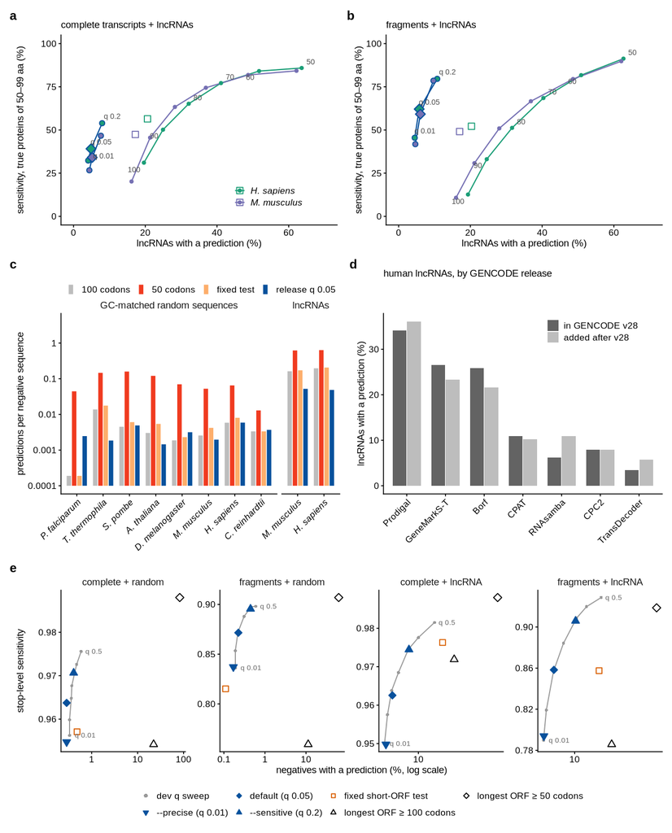

```r
SP_COLOR <- c(human = "#1b9e77", mouse = "#7570b3")
REL_C <- TD_C
tradeoff <- function(vv, title) {
  d <- ab %>% filter(v == vv) %>% mutate(org = factor(org, c("human", "mouse")))
  ggplot(d, aes(x, y, colour = org)) +
    geom_path(data = d %>% filter(path == "minimum") %>% arrange(org, as.integer(sub("m", "", cfg))), linewidth = 0.4) +
    geom_point(data = d %>% filter(path == "minimum"), size = 1) +
    geom_path(data = d %>% filter(path == "release") %>% arrange(org, cfg), colour = REL_C, linewidth = 0.4,
              aes(group = org)) +
    geom_point(data = d %>% filter(path == "release", cfg != "q0.05"), aes(fill = org), shape = 21,
               colour = REL_C, size = 1.4, stroke = 0.5) +
    geom_point(data = d %>% filter(path == "release", cfg == "q0.05"), aes(fill = org), shape = 23,
               colour = REL_C, size = 2.2, stroke = 0.6) +
    geom_point(data = d %>% filter(path == "fixed"), shape = 0, size = 1.8, stroke = 0.5) +
    geom_text_repel(data = d %>% filter(org == "human", path != "fixed"), aes(label = label), size = 1.9,
                    colour = "grey30", min.segment.length = 0.2, seed = 1, box.padding = 0.15) +
    scale_colour_manual(values = SP_COLOR, labels = c(human = "H. sapiens", mouse = "M. musculus"), name = NULL) +
    scale_fill_manual(values = SP_COLOR, guide = "none") +
    scale_x_continuous(limits = c(0, 70)) + scale_y_continuous(limits = c(0, 100)) +
    labs(x = "lncRNAs with a prediction (%)", y = "sensitivity, true proteins of 50–99 aa (%)", title = title) +
    theme(legend.position = c(0.75, 0.15), legend.text = element_text(face = "italic"))
}
pa <- tradeoff("complete.wLnc", "complete transcripts + lncRNAs")
pb <- tradeoff("fragments.wLnc", "fragments + lncRNAs") + theme(legend.position = "none")

CFG_C <- c("100 codons" = "#bdbdbd", "50 codons" = FRAG_C, "fixed test" = "#fdae6b", "release q 0.05" = TD_C)
pc <- ggplot(per_neg, aes(org_lab, colour = cfg)) +
  geom_linerange(aes(ymin = 1e-4, ymax = pmax(per_seq, 1e-4)), position = position_dodge(width = 0.8),
                 linewidth = 1.5) +
  facet_grid(. ~ group, scales = "free_x", space = "free_x") +
  scale_y_log10(limits = c(1e-4, 4), breaks = 10^(-4:0), labels = c("0.0001", "0.001", "0.01", "0.1", "1"),
                oob = scales::squish) +
  scale_colour_manual(values = CFG_C, name = NULL) +
  labs(x = NULL, y = "predictions per negative sequence") +
  theme(axis.text.x = element_text(angle = 45, hjust = 1, face = "italic"), legend.position = "top",
        legend.margin = margin(0, 0, -6, 0))

pd <- ggplot(era_plot, aes(tool, pct, fill = era)) +
  geom_col(position = position_dodge(width = 0.75), width = 0.72) +
  scale_fill_manual(values = c("in GENCODE v28" = "#636363", "added after v28" = "#bdbdbd"), name = NULL) +
  labs(x = NULL, y = "lncRNAs with a prediction (%)", title = "human lncRNAs, by GENCODE release") +
  theme(axis.text.x = element_text(angle = 45, hjust = 1), legend.position = c(0.75, 0.9))

KIND_SHAPE <- c("dev q sweep" = 16, "--precise (q 0.01)" = 25, "default (q 0.05)" = 23, "--sensitive (q 0.2)" = 24,
                "fixed short-ORF test" = 0, "longest ORF ≥ 100 codons" = 2, "longest ORF ≥ 50 codons" = 5)
KIND_COL <- c("dev q sweep" = GREY, "--precise (q 0.01)" = TD_C, "default (q 0.05)" = TD_C,
              "--sensitive (q 0.2)" = TD_C, "fixed short-ORF test" = "#d95f02",
              "longest ORF ≥ 100 codons" = "black", "longest ORF ≥ 50 codons" = "black")
e_dat <- e_dat %>% mutate(kind = factor(kind, names(KIND_SHAPE)))
pe <- ggplot(e_dat, aes(x, y)) +
  geom_path(data = e_dat %>% filter(kind == "dev q sweep") %>% arrange(variant, q), colour = GREY, linewidth = 0.35) +
  geom_point(aes(shape = kind, colour = kind, fill = kind),
             size = ifelse(e_dat$kind == "dev q sweep", 0.7, 1.6), stroke = 0.5) +
  geom_text(data = e_dat %>% filter(kind == "dev q sweep", q %in% c(0.01, 0.5)), aes(label = paste("q", q)),
            size = 1.8, colour = "grey40", hjust = -0.25) +
  facet_wrap(~ variant, nrow = 1, scales = "free") +
  scale_x_log10(breaks = c(0.1, 1, 10, 100), labels = c("0.1", "1", "10", "100")) +
  scale_shape_manual(values = KIND_SHAPE, name = NULL) + scale_colour_manual(values = KIND_COL, name = NULL) +
  scale_fill_manual(values = c(KIND_COL[1:4], "fixed short-ORF test" = NA, "longest ORF ≥ 100 codons" = NA,
                               "longest ORF ≥ 50 codons" = NA), name = NULL) +
  labs(x = "negatives with a prediction (%, log scale)", y = "stop-level sensitivity") +
  theme(legend.position = "bottom", panel.spacing = unit(3, "mm")) +
  guides(shape = guide_legend(nrow = 2), colour = guide_legend(nrow = 2), fill = guide_legend(nrow = 2))

fig4 <- (pa | pb) / (pc | pd) / pe + plot_layout(heights = c(1, 0.95, 0.85)) +
  plot_annotation(tag_levels = "a")
png_f <- save_fig(fig4, "fig4_short_orfs", FULL_W, 8.3)
fig4
```

Plotted values:

```r
details(ab %>% select(org, v, cfg, path, x, y, neg, prec) %>% mutate(across(c(x, y, prec), ~ round(.x, 2))),
        "panels a, b")
```

**panels a, b**

| org | v | cfg | path | x | y | neg | prec |
| --- | --- | --- | --- | --- | --- | --- | --- |
| human | complete.wLnc | m100 | minimum | 19.63 | 31.07 | 6608 | 0.74 |
| human | complete.wLnc | m50 | minimum | 63.61 | 85.89 | 21416 | 0.47 |
| human | complete.wLnc | m50+g200 | fixed | 20.62 | 56.43 | 6943 | 0.73 |
| human | complete.wLnc | m60 | minimum | 51.73 | 84.11 | 17416 | 0.52 |
| human | complete.wLnc | m70 | minimum | 41.11 | 77.14 | 13840 | 0.58 |
| human | complete.wLnc | m80 | minimum | 32.11 | 65.18 | 10812 | 0.63 |
| human | complete.wLnc | m90 | minimum | 24.95 | 50.18 | 8400 | 0.69 |
| human | fragments.wLnc | m100 | minimum | 19.33 | 12.66 | 6508 | 0.70 |
| human | fragments.wLnc | m50 | minimum | 62.67 | 91.30 | 21100 | 0.46 |
| human | fragments.wLnc | m50+g200 | fixed | 20.30 | 52.14 | 6833 | 0.71 |
| human | fragments.wLnc | m60 | minimum | 50.88 | 81.74 | 17131 | 0.50 |
| human | fragments.wLnc | m70 | minimum | 40.35 | 68.49 | 13586 | 0.55 |
| human | fragments.wLnc | m80 | minimum | 31.63 | 51.22 | 10648 | 0.61 |
| human | fragments.wLnc | m90 | minimum | 24.56 | 33.09 | 8270 | 0.66 |
| mouse | complete.wLnc | m100 | minimum | 16.17 | 20.19 | 5088 | 0.80 |
| mouse | complete.wLnc | m50 | minimum | 62.16 | 84.26 | 19560 | 0.52 |
| mouse | complete.wLnc | m50+g200 | fixed | 17.23 | 47.41 | 5423 | 0.79 |
| mouse | complete.wLnc | m60 | minimum | 48.69 | 81.85 | 15320 | 0.58 |
| mouse | complete.wLnc | m70 | minimum | 36.89 | 74.44 | 11608 | 0.64 |
| mouse | complete.wLnc | m80 | minimum | 28.26 | 63.33 | 8894 | 0.70 |
| mouse | complete.wLnc | m90 | minimum | 21.35 | 45.56 | 6717 | 0.75 |
| mouse | fragments.wLnc | m100 | minimum | 15.99 | 10.76 | 5032 | 0.76 |
| mouse | fragments.wLnc | m50 | minimum | 62.07 | 89.80 | 19531 | 0.50 |
| mouse | fragments.wLnc | m50+g200 | fixed | 17.00 | 49.10 | 5348 | 0.77 |
| mouse | fragments.wLnc | m60 | minimum | 48.62 | 79.50 | 15299 | 0.55 |
| mouse | fragments.wLnc | m70 | minimum | 36.86 | 66.63 | 11598 | 0.61 |
| mouse | fragments.wLnc | m80 | minimum | 28.05 | 50.93 | 8827 | 0.67 |
| mouse | fragments.wLnc | m90 | minimum | 21.12 | 30.81 | 6647 | 0.72 |
| human | complete.wLnc | q0.05 | release | 4.87 | 39.11 | 1639 | 0.92 |
| human | complete.wLnc | q0.01 | release | 4.09 | 32.32 | 1378 | 0.93 |
| human | complete.wLnc | q0.2 | release | 7.97 | 53.93 | 2685 | 0.87 |
| human | fragments.wLnc | q0.05 | release | 5.73 | 62.10 | 1928 | 0.89 |
| human | fragments.wLnc | q0.01 | release | 4.48 | 45.48 | 1507 | 0.91 |
| human | fragments.wLnc | q0.2 | release | 10.76 | 79.60 | 3621 | 0.82 |
| mouse | complete.wLnc | q0.05 | release | 5.21 | 34.07 | 1640 | 0.92 |
| mouse | complete.wLnc | q0.01 | release | 4.41 | 26.67 | 1387 | 0.93 |
| mouse | complete.wLnc | q0.2 | release | 7.63 | 46.67 | 2400 | 0.89 |
| mouse | fragments.wLnc | q0.05 | release | 6.05 | 59.19 | 1904 | 0.90 |
| mouse | fragments.wLnc | q0.01 | release | 4.65 | 41.79 | 1464 | 0.92 |
| mouse | fragments.wLnc | q0.2 | release | 9.71 | 78.55 | 3054 | 0.86 |

```r
details(per_neg %>% select(group, org, cfg, neg, n_neg, per_seq) %>% mutate(per_seq = signif(per_seq, 3)), "panel c")
```

**panel c**

| group | org | cfg | neg | n_neg | per_seq |
| --- | --- | --- | --- | --- | --- |
| GC-matched random sequences | athal | 100 codons | 81 | 26867 | 0.003010 |
| GC-matched random sequences | athal | 50 codons | 3244 | 26867 | 0.121000 |
| GC-matched random sequences | athal | fixed test | 146 | 26867 | 0.005430 |
| GC-matched random sequences | creinhardtii | 100 codons | 59 | 17621 | 0.003350 |
| GC-matched random sequences | creinhardtii | 50 codons | 228 | 17621 | 0.012900 |
| GC-matched random sequences | creinhardtii | fixed test | 59 | 17621 | 0.003350 |
| GC-matched random sequences | dmel | 100 codons | 26 | 13884 | 0.001870 |
| GC-matched random sequences | dmel | 50 codons | 970 | 13884 | 0.069900 |
| GC-matched random sequences | dmel | fixed test | 32 | 13884 | 0.002300 |
| lncRNAs | human | 100 codons | 6608 | 33668 | 0.196000 |
| lncRNAs | human | 50 codons | 21416 | 33668 | 0.636000 |
| lncRNAs | human | fixed test | 6943 | 33668 | 0.206000 |
| GC-matched random sequences | human | 100 codons | 112 | 19167 | 0.005840 |
| GC-matched random sequences | human | 50 codons | 1248 | 19167 | 0.065100 |
| GC-matched random sequences | human | fixed test | 154 | 19167 | 0.008030 |
| lncRNAs | mouse | 100 codons | 5088 | 31467 | 0.162000 |
| lncRNAs | mouse | 50 codons | 19560 | 31467 | 0.622000 |
| lncRNAs | mouse | fixed test | 5423 | 31467 | 0.172000 |
| GC-matched random sequences | mouse | 100 codons | 55 | 21409 | 0.002570 |
| GC-matched random sequences | mouse | 50 codons | 1124 | 21409 | 0.052500 |
| GC-matched random sequences | mouse | fixed test | 90 | 21409 | 0.004200 |
| GC-matched random sequences | pfalciparum | 100 codons | 1 | 5281 | 0.000189 |
| GC-matched random sequences | pfalciparum | 50 codons | 235 | 5281 | 0.044500 |
| GC-matched random sequences | pfalciparum | fixed test | 1 | 5281 | 0.000189 |
| GC-matched random sequences | spombe | 100 codons | 23 | 5100 | 0.004510 |
| GC-matched random sequences | spombe | 50 codons | 813 | 5100 | 0.159000 |
| GC-matched random sequences | spombe | fixed test | 31 | 5100 | 0.006080 |
| GC-matched random sequences | tthermophila | 100 codons | 364 | 26456 | 0.013800 |
| GC-matched random sequences | tthermophila | 50 codons | 3871 | 26456 | 0.146000 |
| GC-matched random sequences | tthermophila | fixed test | 467 | 26456 | 0.017700 |
| GC-matched random sequences | athal | release q 0.05 | 39 | 26867 | 0.001450 |
| GC-matched random sequences | creinhardtii | release q 0.05 | 65 | 17621 | 0.003690 |
| GC-matched random sequences | dmel | release q 0.05 | 44 | 13884 | 0.003170 |
| lncRNAs | human | release q 0.05 | 1639 | 33668 | 0.048700 |
| GC-matched random sequences | human | release q 0.05 | 113 | 19167 | 0.005900 |
| lncRNAs | mouse | release q 0.05 | 1640 | 31467 | 0.052100 |
| GC-matched random sequences | mouse | release q 0.05 | 42 | 21409 | 0.001960 |
| GC-matched random sequences | pfalciparum | release q 0.05 | 13 | 5281 | 0.002460 |
| GC-matched random sequences | spombe | release q 0.05 | 25 | 5100 | 0.004900 |
| GC-matched random sequences | tthermophila | release q 0.05 | 49 | 26456 | 0.001850 |

```r
details(era_plot %>% select(tool, era, n_lnc, n_called, pct) %>% mutate(pct = round(pct, 1)), "panel d")
```

**panel d**

| tool | era | n_lnc | n_called | pct |
| --- | --- | --- | --- | --- |
| TransDecoder | in GENCODE v28 | 12987 | 445 | 3.4 |
| TransDecoder | added after v28 | 20681 | 1194 | 5.8 |
| CPAT | in GENCODE v28 | 12987 | 1412 | 10.9 |
| CPAT | added after v28 | 20681 | 2108 | 10.2 |
| CPC2 | in GENCODE v28 | 12987 | 1029 | 7.9 |
| CPC2 | added after v28 | 20681 | 1631 | 7.9 |
| RNAsamba | in GENCODE v28 | 12987 | 810 | 6.2 |
| RNAsamba | added after v28 | 20681 | 2247 | 10.9 |
| Borf | in GENCODE v28 | 12987 | 3362 | 25.9 |
| Borf | added after v28 | 20681 | 4471 | 21.6 |
| GeneMarkS-T | in GENCODE v28 | 12987 | 3449 | 26.6 |
| GeneMarkS-T | added after v28 | 20681 | 4826 | 23.3 |
| Prodigal | in GENCODE v28 | 12987 | 4429 | 34.1 |
| Prodigal | added after v28 | 20681 | 7459 | 36.1 |

```r
details(e_dat %>% select(variant, kind, label, x, y, sens_exact, n_orgs) %>% mutate(across(c(x, y, sens_exact), ~ round(.x, 3))),
        "panel e")
```

**panel e**

| variant | kind | label | x | y | sens_exact | n_orgs |
| --- | --- | --- | --- | --- | --- | --- |
| complete + lncRNA | dev q sweep | decoy_q0.01 | 4.100 | 0.950 | 0.881 | 2 |
| complete + lncRNA | dev q sweep | decoy_q0.02 | 4.430 | 0.958 | 0.888 | 2 |
| complete + lncRNA | dev q sweep | decoy_q0.05 | 4.950 | 0.964 | 0.894 | 2 |
| complete + lncRNA | dev q sweep | decoy_q0.1 | 5.920 | 0.969 | 0.898 | 2 |
| complete + lncRNA | dev q sweep | decoy_q0.2 | 7.670 | 0.975 | 0.904 | 2 |
| complete + lncRNA | dev q sweep | decoy_q0.3 | 10.010 | 0.978 | 0.907 | 2 |
| complete + lncRNA | dev q sweep | decoy_q0.5 | 15.280 | 0.982 | 0.910 | 2 |
| complete + random | dev q sweep | decoy_q0.01 | 0.330 | 0.956 | 0.888 | 8 |
| complete + random | dev q sweep | decoy_q0.02 | 0.330 | 0.960 | 0.891 | 8 |
| complete + random | dev q sweep | decoy_q0.05 | 0.360 | 0.965 | 0.899 | 8 |
| complete + random | dev q sweep | decoy_q0.1 | 0.370 | 0.968 | 0.903 | 8 |
| complete + random | dev q sweep | decoy_q0.2 | 0.420 | 0.970 | 0.905 | 8 |
| complete + random | dev q sweep | decoy_q0.3 | 0.470 | 0.973 | 0.906 | 8 |
| complete + random | dev q sweep | decoy_q0.5 | 0.590 | 0.976 | 0.908 | 8 |
| fragments + lncRNA | dev q sweep | decoy_q0.01 | 4.520 | 0.790 | 0.699 | 2 |
| fragments + lncRNA | dev q sweep | decoy_q0.02 | 4.860 | 0.819 | 0.723 | 2 |
| fragments + lncRNA | dev q sweep | decoy_q0.05 | 5.830 | 0.857 | 0.755 | 2 |
| fragments + lncRNA | dev q sweep | decoy_q0.1 | 7.520 | 0.884 | 0.777 | 2 |
| fragments + lncRNA | dev q sweep | decoy_q0.2 | 10.510 | 0.909 | 0.797 | 2 |
| fragments + lncRNA | dev q sweep | decoy_q0.3 | 13.530 | 0.920 | 0.806 | 2 |
| fragments + lncRNA | dev q sweep | decoy_q0.5 | 19.650 | 0.929 | 0.813 | 2 |
| fragments + random | dev q sweep | decoy_q0.01 | 0.190 | 0.836 | 0.728 | 8 |
| fragments + random | dev q sweep | decoy_q0.02 | 0.190 | 0.854 | 0.746 | 8 |
| fragments + random | dev q sweep | decoy_q0.05 | 0.220 | 0.872 | 0.773 | 8 |
| fragments + random | dev q sweep | decoy_q0.1 | 0.310 | 0.888 | 0.788 | 8 |
| fragments + random | dev q sweep | decoy_q0.2 | 0.430 | 0.896 | 0.798 | 8 |
| fragments + random | dev q sweep | decoy_q0.3 | 0.460 | 0.897 | 0.800 | 8 |
| fragments + random | dev q sweep | decoy_q0.5 | 0.600 | 0.898 | 0.800 | 8 |
| complete + lncRNA | fixed short-ORF test | cliff_c200 | 18.930 | 0.976 | 0.905 | 2 |
| complete + lncRNA | longest ORF ≥ 100 codons | longest_orf_m100 | 25.700 | 0.972 | 0.621 | 2 |
| complete + lncRNA | longest ORF ≥ 50 codons | longest_orf_m50 | 80.870 | 0.988 | 0.634 | 2 |
| complete + random | fixed short-ORF test | cliff_c200 | 0.480 | 0.957 | 0.897 | 8 |
| complete + random | longest ORF ≥ 100 codons | longest_orf_m100 | 22.260 | 0.954 | 0.677 | 8 |
| complete + random | longest ORF ≥ 50 codons | longest_orf_m50 | 82.470 | 0.988 | 0.701 | 8 |
| fragments + lncRNA | fixed short-ORF test | cliff_c200 | 18.650 | 0.858 | 0.753 | 2 |
| fragments + lncRNA | longest ORF ≥ 100 codons | longest_orf_m100 | 25.700 | 0.786 | 0.632 | 2 |
| fragments + lncRNA | longest ORF ≥ 50 codons | longest_orf_m50 | 80.870 | 0.919 | 0.736 | 2 |
| fragments + random | fixed short-ORF test | cliff_c200 | 0.110 | 0.815 | 0.708 | 8 |
| fragments + random | longest ORF ≥ 100 codons | longest_orf_m100 | 11.290 | 0.759 | 0.617 | 8 |
| fragments + random | longest ORF ≥ 50 codons | longest_orf_m50 | 62.590 | 0.907 | 0.760 | 8 |
| complete + lncRNA | --precise (q 0.01) | precise | 4.250 | 0.950 | 0.881 | 2 |
| complete + lncRNA | default (q 0.05) | pytd_v7 | 5.040 | 0.963 | 0.893 | 2 |
| complete + lncRNA | --sensitive (q 0.2) | sensitive | 7.800 | 0.974 | 0.904 | 2 |
| complete + random | --precise (q 0.01) | precise | 0.285 | 0.955 | 0.888 | 8 |
| complete + random | default (q 0.05) | pytd_v7 | 0.285 | 0.964 | 0.899 | 8 |
| complete + random | --sensitive (q 0.2) | sensitive | 0.405 | 0.971 | 0.905 | 8 |
| fragments + lncRNA | --precise (q 0.01) | precise | 4.565 | 0.794 | 0.703 | 2 |
| fragments + lncRNA | default (q 0.05) | pytd_v7 | 5.890 | 0.858 | 0.756 | 2 |
| fragments + lncRNA | --sensitive (q 0.2) | sensitive | 10.235 | 0.906 | 0.795 | 2 |
| fragments + random | --precise (q 0.01) | precise | 0.170 | 0.837 | 0.729 | 8 |
| fragments + random | default (q 0.05) | pytd_v7 | 0.225 | 0.872 | 0.772 | 8 |
| fragments + random | --sensitive (q 0.2) | sensitive | 0.445 | 0.895 | 0.798 | 8 |

## Small inputs and presets

Held-out test of E21 (development code 6b024ca; not rerun at release, see E24 for the bundled presets). Medians over organisms (human, mouse, *A. thaliana*, *D. melanogaster*) and replicates. `self_cliff` / `self_decoy` = trained on the input with the fixed test or the q-value test (q 0.05); `preset_same` = same-species preset from complete transcripts; `preset_samemix` = from complete transcripts and fragments; `preset_other` = mouse for human, human for the others.

```r
pm <- presets %>% group_by(set, label) %>%
  summarise(across(c(sens_stop, sens_exact, precision_stop, neg_rate), median), n = n(), .groups = "drop") %>%
  mutate(input = sub("\\..*", "", set), kind = ifelse(grepl("codingonly", set), "coding only", "half random"),
         size = as.integer(sub(".*\\.[BC]", "", set)))
pv <- function(input, kind, size, label, col) pm[[col]][pm$input == input & pm$kind == kind & pm$size == size & pm$label == label]
tab_p <- pm %>% filter(kind == "half random") %>% mutate(v = sprintf("%.3f / %.1f", sens_stop, 100 * neg_rate)) %>%
  select(input, size, label, v) %>% pivot_wider(names_from = label, values_from = v) %>% arrange(input, size)
kable(tab_p, caption = "stop sensitivity / % random sequences with a prediction")
```

stop sensitivity / % random sequences with a prediction

| input | size | preset_other | preset_same | preset_samemix | self_cliff | self_decoy |
| --- | --- | --- | --- | --- | --- | --- |
| complete | 50 | 0.940 / 0.0 | 0.980 / 0.0 | 0.960 / 0.0 | 1.000 / 68.0 | 1.000 / 82.0 |
| complete | 200 | 0.915 / 0.0 | 0.960 / 0.0 | 0.960 / 0.0 | 0.990 / 64.0 | 0.990 / 52.5 |
| complete | 500 | 0.900 / 0.4 | 0.952 / 0.4 | 0.948 / 0.0 | 0.984 / 15.0 | 0.986 / 7.6 |
| complete | 1000 | 0.913 / 0.3 | 0.956 / 0.4 | 0.958 / 0.2 | 0.967 / 0.9 | 0.979 / 0.8 |
| complete | 5000 | 0.914 / 0.3 | 0.958 / 0.3 | 0.956 / 0.2 | 0.963 / 0.5 | 0.967 / 0.6 |
| fragments | 50 | 0.740 / 0.0 | 0.840 / 0.0 | 0.860 / 0.0 | 0.880 / 52.0 | 0.920 / 62.0 |
| fragments | 200 | 0.740 / 0.0 | 0.815 / 0.0 | 0.875 / 0.0 | 0.875 / 45.0 | 0.920 / 57.0 |
| fragments | 500 | 0.718 / 0.0 | 0.804 / 0.4 | 0.866 / 0.2 | 0.884 / 24.0 | 0.898 / 24.6 |
| fragments | 1000 | 0.712 / 0.2 | 0.796 / 0.3 | 0.854 / 0.2 | 0.825 / 3.8 | 0.868 / 3.7 |
| fragments | 5000 | 0.723 / 0.2 | 0.806 / 0.2 | 0.873 / 0.3 | 0.816 / 0.1 | 0.880 / 0.3 |

```r
details(pm %>% filter(kind == "coding only") %>% select(input, size, label, sens_stop, sens_exact, precision_stop),
        "coding-only inputs")
```

**coding-only inputs**

| input | size | label | sens_stop | sens_exact | precision_stop |
| --- | --- | --- | --- | --- | --- |
| complete | 1000 | preset_other | 0.9210 | 0.8565 | 0.99780 |
| complete | 1000 | preset_same | 0.9585 | 0.8950 | 0.99840 |
| complete | 1000 | preset_samemix | 0.9590 | 0.8935 | 0.99840 |
| complete | 1000 | self_cliff | 0.9645 | 0.8965 | 0.99900 |
| complete | 1000 | self_decoy | 0.9710 | 0.9015 | 0.99795 |
| complete | 200 | preset_other | 0.9075 | 0.8325 | 1.00000 |
| complete | 200 | preset_same | 0.9650 | 0.8975 | 1.00000 |
| complete | 200 | preset_samemix | 0.9650 | 0.8925 | 1.00000 |
| complete | 200 | self_cliff | 0.9900 | 0.8150 | 0.99000 |
| complete | 200 | self_decoy | 0.9900 | 0.8200 | 0.99495 |
| complete | 50 | preset_other | 0.9300 | 0.8300 | 1.00000 |
| complete | 50 | preset_same | 0.9600 | 0.9000 | 1.00000 |
| complete | 50 | preset_samemix | 0.9600 | 0.8800 | 1.00000 |
| complete | 50 | self_cliff | 0.9800 | 0.8000 | 1.00000 |
| complete | 50 | self_decoy | 0.9800 | 0.8100 | 1.00000 |
| fragments | 1000 | preset_other | 0.7140 | 0.6200 | 0.99690 |
| fragments | 1000 | preset_same | 0.7985 | 0.7020 | 0.99680 |
| fragments | 1000 | preset_samemix | 0.8590 | 0.7610 | 0.99540 |
| fragments | 1000 | self_cliff | 0.8025 | 0.7115 | 0.99760 |
| fragments | 1000 | self_decoy | 0.8690 | 0.7705 | 0.99655 |
| fragments | 200 | preset_other | 0.7275 | 0.6325 | 1.00000 |
| fragments | 200 | preset_same | 0.8100 | 0.7075 | 0.99410 |
| fragments | 200 | preset_samemix | 0.8550 | 0.7625 | 1.00000 |
| fragments | 200 | self_cliff | 0.9175 | 0.7850 | 0.98655 |
| fragments | 200 | self_decoy | 0.9225 | 0.7950 | 0.98685 |
| fragments | 50 | preset_other | 0.7100 | 0.6200 | 1.00000 |
| fragments | 50 | preset_same | 0.8000 | 0.7000 | 1.00000 |
| fragments | 50 | preset_samemix | 0.8400 | 0.7400 | 1.00000 |
| fragments | 50 | self_cliff | 0.8900 | 0.6800 | 0.95875 |
| fragments | 50 | self_decoy | 0.9100 | 0.7300 | 0.95830 |

```r
small_rand <- pm %>% filter(kind == "half random", input == "complete", size <= 500, label %in% c("self_cliff", "self_decoy"))
preset_rand <- pm %>% filter(kind == "half random", label %in% c("preset_same", "preset_samemix"))
mix <- pm %>% filter(kind == "half random", label == "preset_samemix")
# cross-clade transfer, per organism (5,000 fragments)
cross <- presets %>% filter(set == "fragments.wRand.B5000", label %in% c("preset_other", "preset_samemix")) %>%
  select(org, label, sens_stop) %>% pivot_wider(names_from = label, values_from = sens_stop)
kable(cross, digits = 3, caption = "fragments + random, 5,000 sequences: other-species vs same-species (mix) preset")
```

fragments + random, 5,000 sequences: other-species vs same-species (mix) preset

| org | preset_samemix | preset_other |
| --- | --- | --- |
| athal | 0.815 | 0.435 |
| dmel | 0.880 | 0.664 |
| mouse | 0.868 | 0.781 |
| human | 0.878 | 0.810 |

```r
check_text("<=500 seqs, random calls trained on input, min (%)", round(100 * min(small_rand$neg_rate)), 8)
check_text("<=500 seqs, random calls trained on input, max (%)", round(100 * max(small_rand$neg_rate)), 82)
check_text("1,000 seqs, random calls complete (%)", round(100 * pv("complete", "half random", 1000, "self_decoy", "neg_rate"), 1), 0.8)
check_text("1,000 seqs, random calls fragments (%)", round(100 * pv("fragments", "half random", 1000, "self_decoy", "neg_rate"), 1), 3.7)
check_text("5,000 seqs, random calls complete (%)", round(100 * pv("complete", "half random", 5000, "self_decoy", "neg_rate"), 1), 0.6)
check_text("5,000 seqs, random calls fragments (%)", round(100 * pv("fragments", "half random", 5000, "self_decoy", "neg_rate"), 1), 0.3)
check_text("preset random calls, max (%)", round(100 * max(preset_rand$neg_rate), 1), 0.4)
check_text("preset random calls, min (%)", round(100 * min(preset_rand$neg_rate), 1), 0)
check_text("mix preset stop sens complete, min", round(min(mix$sens_stop[mix$input == "complete"]), 3), 0.948)
check_text("mix preset stop sens complete, max", round(max(mix$sens_stop[mix$input == "complete"]), 3), 0.960)
check_text("mix preset stop sens fragments, min", round(min(mix$sens_stop[mix$input == "fragments"]), 3), 0.854)
check_text("mix preset stop sens fragments, max", round(max(mix$sens_stop[mix$input == "fragments"]), 3), 0.875)
check_text("trained on 5,000, stop sens complete", round(pv("complete", "half random", 5000, "self_decoy", "sens_stop"), 3), 0.967)
check_text("trained on 5,000, stop sens fragments", round(pv("fragments", "half random", 5000, "self_decoy", "sens_stop"), 3), 0.880)
check_text("50 complete coding, exact sens trained on input", round(pv("complete", "coding only", 50, "self_decoy", "sens_exact"), 2), 0.81)
check_text("50 complete coding, exact sens with mix preset", round(pv("complete", "coding only", 50, "preset_samemix", "sens_exact"), 2), 0.88)
check_text("complete-only preset, fragments 5,000", round(pv("fragments", "half random", 5000, "preset_same", "sens_stop"), 3), 0.806)
check_text("mix preset, fragments 5,000", round(pv("fragments", "half random", 5000, "preset_samemix", "sens_stop"), 3), 0.873)
check_text("mix preset, complete 5,000", round(pv("complete", "half random", 5000, "preset_samemix", "sens_stop"), 3), 0.956)
check_text("complete-only preset, complete 5,000", round(pv("complete", "half random", 5000, "preset_same", "sens_stop"), 3), 0.958)
check_text("other-species preset, fragments 5,000 (median of 4 organisms)", round(pv("fragments", "half random", 5000, "preset_other", "sens_stop"), 2), 0.72)
check_text("cross-clade preset only (A. thaliana, D. melanogaster), fragments 5,000, max",
           round(max(cross$preset_other[cross$org %in% c("athal", "dmel")]), 2), 0.66)
check_text("cross-clade preset only (A. thaliana, D. melanogaster), fragments 5,000, min",
           round(min(cross$preset_other[cross$org %in% c("athal", "dmel")]), 2), 0.43)  # 1087/2500 = 0.4348; text said 0.44 until 2026-10-30
check_text("human/mouse other-species preset, fragments 5,000, min",
           round(min(cross$preset_other[cross$org %in% c("human", "mouse")]), 2), 0.78)
check_text("human/mouse other-species preset, fragments 5,000, max",
           round(max(cross$preset_other[cross$org %in% c("human", "mouse")]), 2), 0.81)
check_text("same-species mix preset, fragments 5,000", round(pv("fragments", "half random", 5000, "preset_samemix", "sens_stop"), 2), 0.87)
```

- Trained on the input, complete transcripts, 50–500 sequences: 7.6–82.0% of random sequences with a prediction (fixed test or q-value test). With 1,000 sequences 0.8% (complete) and 3.7% (fragments); with 5,000 0.6% and 0.3%.
- Same-species presets: random calls 0.0–0.4%; with the mixed preset, stop sensitivity 0.948–0.960 (complete) and 0.854–0.875 (fragments), against 0.967 and 0.880 trained on 5,000 sequences.
- 50 complete coding transcripts: exact-CDS sensitivity 0.810 trained on the input, 0.880 with the mixed preset and 0.900 with the complete-only preset.
- Fragments, 5,000: complete-only preset 0.806, mixed preset 0.873; complete, 5,000: mixed 0.956, complete-only 0.958.
- Other-species presets on fragments (5,000): median 0.723 over the four organisms. This median mixes mouse ↔︎ human transfers (0.810, 0.781) with the cross-clade transfers human → *A. thaliana* (0.435) and human → *D. melanogaster* (0.664). The text's "across clades ... 0.72" therefore understates the cross-clade loss.

## Methods: target-decoy q-values

The q-value paragraphs of `methods_algorithm.tex` give settings rather than measured values. Those that can be checked against committed data:

```r
pj <- jsonlite::fromJSON(data_path("benchmark", "presets", "preset_meta", "humanmix", "preset.json"))
rel_q <- c(default = 0.05, precise = 0.01, sensitive = 0.2)  # E24/E25 run labels pytd_v7, _precise, _sensitive
check_text("preset q levels (count)", length(pj$q_levels), 10)
check_text("preset q levels, min", min(pj$q_levels), 0.001)
check_text("preset q levels, max", max(pj$q_levels), 0.5)
check_text("preset strata include transcript length and type", as.numeric(pj$strata == "len_tx_type"), 1)
```

- Presets store 10 q levels from 0.001 to 0.5 (0.001, 0.002, 0.005, 0.01, 0.02, 0.05, 0.1, 0.2, 0.3, 0.5); strata len_tx_type. The release settings 0.01, 0.05 and 0.2 are among them.
- Default q 0.05, `--precise` 0.01 and `--sensitive` 0.2 are the settings of the release runs scored above (E24, E25); the numbers that justify them are in *One setting*.
- The forward-frame versus all-frame contrast comparison and the long-ORF rule paragraph are covered by notebook 01 (E26, E10).

## Checks against the manuscript

Each row compares the value computed here (release runs where they exist, see the labels) with the value the manuscript quotes; the text quotes the release runs wherever one exists.

```r
check_report()
```

| claim | computed | manuscript | ok |
| --- | --- | --- | --- |
| random calls per sequence at 50 codons, min | 0.013 | 0.013 | TRUE |
| random calls per sequence at 50 codons, max | 0.159 | 0.159 | TRUE |
| human lncRNA negatives | 33668 | 33668 | TRUE |
| human 50-99 aa sensitivity, 100 codons | 0.31 | 0.31 | TRUE |
| human 50-99 aa sensitivity, 50 codons | 0.86 | 0.86 | TRUE |
| human lncRNAs with prediction, 100 codons (%) | 19.6 | 19.6 | TRUE |
| human lncRNAs with prediction, 50 codons (%) | 63.6 | 63.6 | TRUE |
| human precision, 100 codons | 0.74 | 0.74 | TRUE |
| human precision, 50 codons | 0.47 | 0.47 | TRUE |
| lncRNA calls of 50-99 aa at 50 codons | 14880 | 14880 | TRUE |
| correct calls of 50-99 aa at 50 codons | 430 | 430 | TRUE |
| complete + random sens_stop, q-value test | 0.964 | 0.964 | TRUE |
| complete + random sens_stop, fixed short-ORF test | 0.9571 | 0.957 | TRUE |
| complete + random sens_exact, q-value test | 0.899 | 0.899 | TRUE |
| complete + random sens_exact, fixed short-ORF test | 0.89685 | 0.897 | TRUE |
| complete + random neg_rate, q-value test | 0.29 | 0.29 | TRUE |
| complete + random neg_rate, fixed short-ORF test | 0.48 | 0.48 | TRUE |
| fragments + random sens_stop, q-value test | 0.872 | 0.872 | TRUE |
| fragments + random sens_stop, fixed short-ORF test | 0.81515 | 0.815 | TRUE |
| fragments + random sens_exact, q-value test | 0.772 | 0.772 | TRUE |
| fragments + random sens_exact, fixed short-ORF test | 0.7081 | 0.708 | TRUE |
| fragments + random neg_rate, q-value test | 0.23 | 0.23 | TRUE |
| fragments + random neg_rate, fixed short-ORF test | 0.115 | 0.11 | TRUE |
| complete + lncRNA neg_rate, q-value test | 5 | 5 | TRUE |
| complete + lncRNA neg_rate, fixed short-ORF test | 18.925 | 18.9 | TRUE |
| fragments + lncRNA neg_rate, q-value test | 5.9 | 5.9 | TRUE |
| fragments + lncRNA neg_rate, fixed short-ORF test | 18.65 | 18.7 | TRUE |
| complete + lncRNA sens_stop, q-value test | 0.963 | 0.963 | TRUE |
| complete + lncRNA sens_stop, fixed short-ORF test | 0.9763 | 0.976 | TRUE |
| fragments + lncRNA sens_stop, q-value test | 0.858 | 0.858 | TRUE |

[output cut: 72 more lines]